# Simulations for ‘Characterising the use of internal meta-analyses and assessing their impact’

Mandy Norrbo & Lisa DeBruine

27/02/2020

# Dependencies

```r
library(tidyverse)
library(metafor)
library(colorspace)
library(knitr)
```

# Define functions

## sim_func()

A function for simulating an independent samples t-test with sample size n and population effect size d. Observed scores are drawn from a normal distribution. The function lists resulting effect size (Cohen’s d) and p-value.

```r
sim_func <- function(n, d = 0) {
  dat <- tibble(
    grp = rep(LETTERS[1:2], each = n),
    score = c(rnorm(n, d, 1), rnorm(n, 0, 1)
  ))
  #t-test on simulated data
  myt <- t.test(score ~ grp, dat)
  #get p-value
  p <- myt$p.value
  #get effect size
  es <- cohens_d(myt$statistic[[1]], n, n)
  list("p" = p, "es" = es)
}
```

## cohens_d()

A function for calculating Cohen’s d for an independent samples t-test using a formula from Lakens (2013). The function requires a t-statistic and two sample sizes.

```r
cohens_d <- function(t, n1, n2 = n1){
  t*sqrt(1/n1 + 1/n2)
}
```

## var_d()

A function for calculating variance needed to calculate internal meta-analysis. The formula was obtained from Vosgerau, Simonsohn, Nelson, & Simmons (2019). Requires an effect size and a sample size.

```r
var_d <- function(d,n){
  df <- (2*n-2)
  (2/n+(d^2)/(2*df)) * ((2*n)/(df))
}
```

## mini_meta()

A function that runs an internal meta-analysis for a user-specified number of studies, with a population effect size d and sample size n (per group). Can use methods available in rma(), here “FE” (fixed effect) and “HE” (random effects).

```r
mini_meta <- function(n.studies = 4, # no. of studies
                      d, # effect size
                      n, # sample size (per group)
                      method = "HE"){ # method for rma()

  study.ps <- vector() # vector for p-values
  study.effects <- vector() # vector for effect sizes
  study.var <- vector() # vector for variances

  for (i in 1:n.studies) { # loop until specified number of studies is reached
    study <- sim_func(n, d) # simulate study with n sample and d effect size
    study.ps[i] <- study$p # p-values in vector
    study.effects[i] <- study$es # effect sizes in vector
    study.var[i] <- var_d(study.effects[i], n) # variances in vector
  }
  # run internal meta-analysis
  minimeta <- rma(yi = study.effects, vi = study.var, method = method)

  data.frame( # add results to a data.frame
    study = 1:length(study.ps),
    p = study.ps,
    es = study.effects
  ) %>%
    add_row(
      study = 0, # internal meta-analysis results
      p = minimeta$pval, # meta-analysed p-value
      es = minimeta$beta[[1]] # meta-analysed effect size
    )
}
```

## p_bound_meta()

A function that runs a user-specified number of studies all with a group sample size of n and true effect size of d. If specified conditions are met (e.g. first p-value < 0.05 and last p-value < 0.1), then results are mini meta-analysed. Can run fixed-effect or random-effects models (specified using “method”).

```r
p_bound_meta <- function(n.studies = 7, # no. of studies
                         d, # effect size
                         n, # sample size
                         method = "HE", # method for rma()
                         pmax.first = .05, # threshold for first p
                         pmax.last = .05){ # threshold for last p
  study.ps <- vector() # vector for p-values
  study.effects <- vector() # vector for effect sizes
  study.var <- vector() # vector for variances

  study <- sim_func(n, d) # simulate first study
  study.ps[1] <- study$p
  study.effects[1] <- study$es
  study.var[1] <- var_d(study.effects[1], n)

  if (study.ps[1] >= pmax.first) { # if first study p > pmax.first
    tbl <- data.frame( # create table of results
      study = 1,
      p = study.ps,
      es = study.effects,
      id = 0 # id studies that did not pass threshold
    )
    return(tbl)
  }
  # else, keep running studies until n.studies
  for (i in 2:n.studies) {
    study <- sim_func(n, d)
    study.ps[i] <- study$p
    study.effects[i] <- study$es
    study.var[i] <- var_d(study.effects[i], n)

    # unless p < pmax.last, then stop running more studies
    if (study$p < pmax.last) break
  }
  # run internal meta-analysis
  minimeta <- rma(yi = study.effects, vi = study.var, method = method)

  data.frame( # add results to a dataframe
    study = 1:length(study.ps),
    p = study.ps,
    es = study.effects,
    id = rep(1, each = length(study.ps))) %>%
      add_row(
      study = 0, # meta-analysis results
      p = minimeta$pval, # meta-analysed p-value
      es = minimeta$beta[[1]] # meta-analyseds effect size
    )
}
```

## meta_hack()

A function that runs an internal meta-analysis after every new study is added. It allows user to specify both a first p-value threshold (pmax.first) as well as a ‘minitarget’, i.e. a threshold for the meta-analysed p-value that stops the running of more studies (unless max number of studies is reached before).

```r
meta_hack <- function(n.studies = 7, # no. of studies
                      d, # effect size
                      n, # sample size
                      method = "HE", # method for rma()
                      pmax.first = .05, # first p threshold
                      minitarget = .05){ # meta-analysed p threshold
  # setting up results vectors
  study.ps <- vector()
  study.effects <- vector()
  study.var <- vector()

  # results of first study
  study <- sim_func(n, d)
  study.ps[1] <- study$p
  study.effects[1] <- study$es
  study.var[1] <- var_d(study.effects[1], n)

  if (study.ps[1] >= pmax.first) { # if first study p > pmax.first
    tbl <- data.frame( # create table of results
      study = 1,
      p = study.ps,
      es = study.effects,
      id = 0) # id studies that did not pass threshold
    return(tbl)
  }

  # else, keep running studies until n.studies or
  for (i in 2:n.studies) {
    study <- sim_func(n, d)
    study.ps[i] <- study$p
    study.effects[i] <- study$es
    study.var[i] <- var_d(study.effects[i], n)
    # meta p < minitarget
    minimeta <- rma(yi = study.effects, vi = study.var, method = method)
    if (minimeta$pval < minitarget) break
  }
  data.frame( # add results to data frame
    study = 1:length(study.ps),
    p = study.ps,
    es = study.effects,
    id = rep(1, each = length(study.ps))
  ) %>%
    add_row(
      study = 0, # meta-analysis results
      p = minimeta$pval, # meta p
      es = minimeta$beta[[1]] # meta es
    )
  }
```

# Analysis

## Power

### Simulation 1

Simulation 1 is a power analysis for fixed and random effects internal meta-analyses, with varied number of studies, effect sizes and sample sizes. The simulation was split by number of studies (2, 3, 4, and 5) to reduce the duration of a single simulation. Iterations were also kept at 1000 to save time.

**Parameters**

- Iterations: 1000
- Number of studies: 2-5
- Effect size: 0-1
- Sample sizes: 50-250
- Method: random (HE) and fixed (FE) effects

```r
set.seed(1337) # reproducible seed

params <- crossing( # all simulation parameters are fully crossed
  n.studies = c(2:5),
  n = seq(50, 250, 50),
  d = seq(0, 1, 0.1),
  iter = 1:1000,
  method = c("HE", "FE")
)

power_tmp <- purrr::pmap_dfr(params, function(...) {
  dots <- list(...)
  mini_meta(n.studies = dots$n.studies,
                 d = dots$d,
                 n = dots$n,
                 method = dots$method) %>%
    mutate(!!!dots)
})

save(power_tmp, file = "power_fpr_tmp.RData")

# create dataframe of results
power_dat <- power_tmp %>%
  filter(study == 0) %>%
  group_by(n, method, d, n.studies) %>%
  summarise(power = mean(p < .05)) %>% # calculate power
  ungroup()

save(power_dat, file = "power_dat.RData")
```

### Visualisation 1

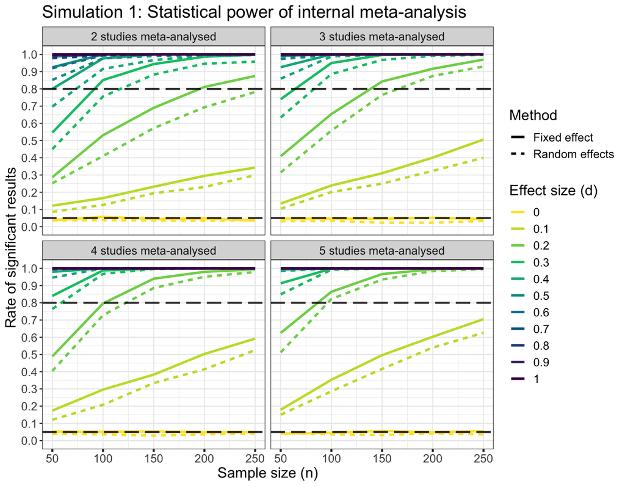

```r
# load saved simulation results from chunk above
#load("power_fpr_tmp.RData)
load("power_dat.RData")

# facet labels
nstudies_labs <- c('2' = "2 studies meta-analysed",
                   '3' = "3 studies meta-analysed",
                   '4' = "4 studies meta-analysed",
                   '5' = "5 studies meta-analysed")


# plot
ggplot(power_dat, aes(n, power)) +
  geom_line(aes(color = factor(d),
                linetype = factor(method)), size=1.2) +
  facet_wrap(~n.studies,
             labeller = as_labeller(nstudies_labs)) +
  scale_y_continuous(limits = c(0, 1),
                     breaks = seq(0, 1, 0.1)) +
  scale_x_continuous(limits = c(50, 250),
                     breaks = seq(50, 250, 50)) +
  theme_bw() +
  scale_color_discrete_sequential("Viridis", name = "Effect size (d)") +
  scale_linetype(name = "Method",
                 labels = c("Fixed effect", "Random effects")) +
  theme(axis.title = element_text(size = 15),
        title = element_text(size = 15),
        axis.text = element_text(size = 10),
        axis.ticks.x = element_line(size = 1),
        axis.text.x = element_text(size=12),
        axis.text.y = element_text(size=12),
        legend.text = element_text(size = 12),
        strip.text.x = element_text(size = 12)) +
  labs(x = "Sample size (n)",
       y = "Rate of significant results",
       title = "Simulation 1: Statistical power of internal meta-analysis") +
  geom_hline(yintercept = 0.8, size = 1, alpha = 0.8, linetype = "longdash") +
  geom_hline(yintercept = 0.05, size = 1, alpha = 0.8, linetype = "longdash")
```

```r
# ggsave("minimeta_power_plot.png", width = 10, height = 7)
```

## p-threshold

### Simulation 2

**Parameters**

```r
set.seed(1337) # reproducible seed


# simulation parameters
params <- crossing(
  i = 1:10000, # iterations
  n.studies = c(4, 8), # maximum no. of studies (based on lit coding)
  n = seq(50, 250, 50), # vector of sample sizes (based on lit coding)
  d = 0, # population effect size
  pmax.first = c(0.05, 0.1), # vector of first p-values (based on lit coding)
  pmax.last = c(0.05,0.1), # vector of last p-values (based on lit coding)
  method = c("HE", "FE")
)

# using p_bound_meta()

pbound_tmp <- purrr::pmap_dfr(params, function(...) {
  dots <- list(...)
  p_bound_meta(n.studies = dots$n.studies,
                 d = dots$d,
                 n = dots$n,
                 method = dots$method,
                 pmax.first = dots$pmax.first,
                 pmax.last = dots$pmax.last) %>%
    mutate(!!!dots)
})

# save all results
save(pbound_tmp, file = "pbound_tmp.RData")

# calculate how many meta-analysed p-values
outof <- pbound_tmp %>%
  filter(study == 0) %>%
  group_by(pmax.first, pmax.last, n, method, d, n.studies) %>%
  count() %>%
  rename(metatotal = nn) %>%
  ungroup()

dat <- pbound_tmp %>%
  filter(study == 0, p < .05) %>% # all significant meta results
  group_by(pmax.first, pmax.last, n, method, d, n.studies) %>%
  count() %>%
  ungroup()

pbound_dat <- left_join(dat, outof, by = c("n", "method", "pmax.first", "pmax.last", "n.studies")) %>%
  select(n, method, nn, metatotal, pmax.first, pmax.last, n.studies) %>%
  mutate(power = nn/metatotal) # calculate false positive rate

# save false positive rates for each combination
save(pbound_dat, outof, file = "pbound_dat.RData")
```

### Visualisation 2

The colourblind-friendly palette used in the plot was obtained from Okaboe & Ito (2002).

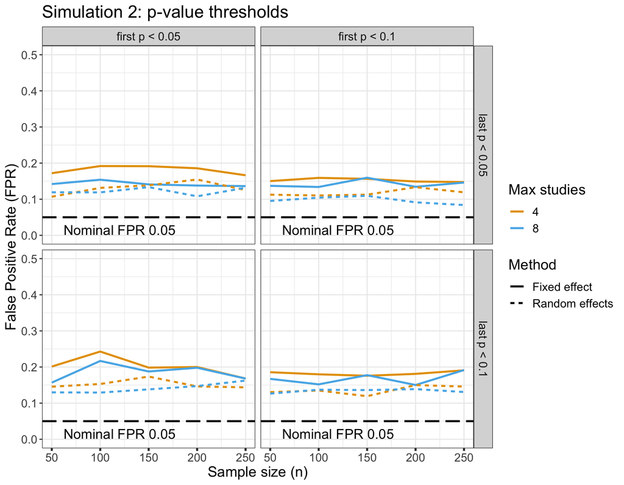

```r
#load("pbound_tmp.RData")
load("pbound_dat.RData") # load saved results for plot

# colourblind-friendly palette
cbPalette <- c("#E69F00", "#56B4E9", "#009E73",
               "#F0E442", "#0072B2", "#D55E00", "#CC79A7")

pbound_dat <- pbound_dat %>%
  rename(Method = method) %>%
  mutate(Method = recode(Method, "HE" = "Random effects", "FE" = "Fixed effect"))

ggplot(pbound_dat, aes(n, power)) +
  geom_line(aes(linetype = Method,
                color = factor(n.studies)), size=1) +
  scale_y_continuous(limits = c(0, 0.5),
                     breaks = seq(0, 0.5, 0.1)) +
  scale_x_continuous(limits = c(50, 250),
                     breaks = seq(50, 250, 50)) +
  geom_hline(yintercept = 0.05, size = 1,
             linetype = "longdash") +
  scale_color_manual(values=cbPalette, name = "Max studies") +
  theme_bw() +
  theme(axis.title = element_text(size = 15),
        title = element_text(size = 15),
        axis.text = element_text(size = 10),
        axis.ticks.x = element_line(size = 1),
        axis.text.x = element_text(size=12),
        axis.text.y = element_text(size=12),
        legend.text = element_text(size = 12),
        strip.text = element_text(size = 12)) +
  labs(x = "Sample size (n)",
       y = "False Positive Rate (FPR)",
       title = "Simulation 2: p-value thresholds") +
  annotate("text", x = 120, y = 0.015,
           label = "Nominal FPR 0.05", size = 5) +
  facet_grid(pmax.last ~ pmax.first, labeller = labeller(
    pmax.last = c("0.05" = "last p < 0.05", "0.1" = "last p < 0.1"),
    pmax.first = c("0.05" = "first p < 0.05", "0.1" = "first p < 0.1")
  ))
```

```r
# ggsave("minimeta_pbound_plot.png", width = 10, height = 7)
```

## Meta-hacking

### Simulation 3

**Parameters**

```r
set.seed(1337) # reproducible seed

# simulation parameters
params <- crossing(
  i = 1:10000, # iterations
  n.studies = c(4,8), # max no. of studies
  d = 0, # true effect size
  n = seq(50, 250, 50), # vector of sample sizes
  pmax.first = 0.05, # first p-value threshold
  minitarget = 0.05, # minimeta threshold
  method = c("HE", "FE") # random (HE) and fixed effect (FE)
)

# simulation
metahack_tmp <- purrr::pmap_dfr(params, function(...) {
  dots <- list(...)
  meta_hack(n.studies = dots$n.studies,
                 d = dots$d,
                 n = dots$n,
                 method = dots$method,
                 pmax.first = dots$pmax.first,
                 minitarget = dots$minitarget) %>%
    mutate(!!!dots)
})


# save all results
save(metahack_tmp, file = "metahack_tmp.RData")

# all meta-analysed p-values
outof <- metahack_tmp %>%
  filter(study == 0) %>%
  group_by(pmax.first, minitarget, n, method, d, n.studies) %>%
  count() %>%
  rename(metatotal = nn) %>%
  ungroup()

# all significant meta-analysed p-values
dat <- metahack_tmp %>%
  filter(study == 0, p < .05) %>% # all significant meta results
  group_by(pmax.first, minitarget, n, method, d, n.studies) %>%
  count() %>%
  ungroup()

metahack_dat <- left_join(dat, outof, by = c("n", "method", "pmax.first", "minitarget", "n.studies")) %>%
  ungroup() %>%
  select(n, method, nn, metatotal, n.studies) %>%
  mutate(power = nn/metatotal) # calculate false positive rate

# save false positive rate results
save(dat, outof, metahack_dat, file = "metahack_dat.RData")
```

### Visualisation 3

The colourblind-friendly palette used in the plot was obtained from Okaboe & Ito (2002).

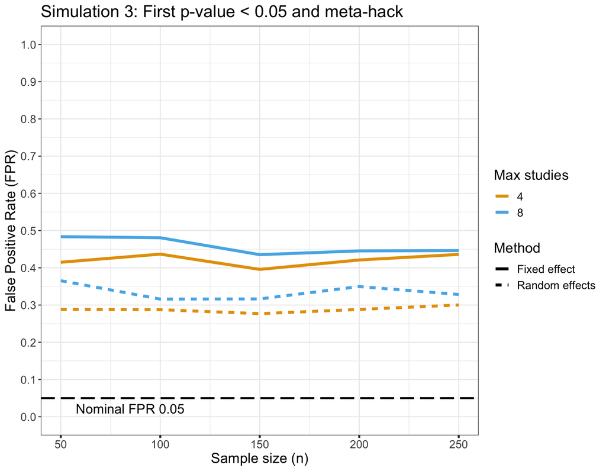

```r
#load("metahack_tmp.RData")
load("metahack_dat.RData") # load saved results for plot

# changing column and row names for plot
metahack_dat <- metahack_dat %>%
  rename(Method = method) %>%
  mutate(Method = recode(Method, "HE" = "Random effects", "FE" = "Fixed effect"))

# colourblind-friendly palette
cbPalette <- c("#E69F00", "#56B4E9", "#009E73",
               "#F0E442", "#0072B2", "#D55E00", "#CC79A7")

ggplot(metahack_dat, aes(n, power)) +
  geom_line(aes(linetype = Method,
                color = factor(n.studies)), size=1.5) +
  scale_y_continuous(limits = c(0, 1),
                     breaks = seq(0, 1, 0.1)) +
  scale_x_continuous(limits = c(50, 250),
                     breaks = seq(50, 250, 50)) +
  geom_hline(yintercept = 0.05, size = 1, linetype = "longdash") +
  scale_color_manual(values=cbPalette, name = "Max studies") +
  theme_bw() +
  theme(axis.title = element_text(size = 15),
        title = element_text(size = 15),
        axis.text = element_text(size = 10),
        axis.ticks.x = element_line(size = 1),
        axis.text.x = element_text(size=12),
        axis.text.y = element_text(size=12),
        legend.text = element_text(size = 12)) +
  labs(x = "Sample size (n)",
       y = "False Positive Rate (FPR)",
       title = "Simulation 3: First p-value < 0.05 and meta-hack") +
  annotate("text", x = 85, y = 0.022,
           label = "Nominal FPR 0.05", size = 5)
```

```r
# ggsave("minimeta_metahack_plot.png", width = 10, height = 7)
```

# Table & Analyses

```r
load("pbound_tmp.RData")
load("metahack_tmp.RData")

# p-threshold table results

# number of total simulations
total_simulations <- pbound_tmp %>%
  filter(study == 1) %>%
  group_by(pmax.first, pmax.last) %>%
  count() %>%
  ungroup()

# number of studies that didnt continue running studies
did_not_meet <- pbound_tmp %>%
  filter(id == 0) %>%
  group_by(pmax.first, pmax.last) %>%
  count() %>%
  ungroup()

# number of significant meta-analyses
sig_meta <- pbound_tmp %>%
  filter(study == 0, p < 0.05) %>%
  group_by(pmax.first, pmax.last) %>%
  count()  %>%
  ungroup()

# number of not significant meta-analyses
not_sig_meta <- pbound_tmp %>%
  filter(study == 0, p > 0.05) %>%
  group_by(pmax.first, pmax.last) %>%
  count()  %>%
  ungroup()



pbound_table <- t(tibble(total_simulations[,1:2],
                       didnotmeet = round(did_not_meet$n/total_simulations$n, 2),
                       sigmeta = round(sig_meta$n/total_simulations$n, 2),
                       nonsigmeta = round(not_sig_meta$n/total_simulations$n, 2)))

# metahack table

# number of total simulations
total_simulations <- metahack_tmp %>%
  filter(study == 1) %>%
  count()

# number of studies that didnt continue running studies
did_not_meet <- metahack_tmp %>%
  filter(id == 0) %>%
  count()

# number of significant meta-analyses
sig_meta <- metahack_tmp %>%
  filter(study == 0, p < 0.05) %>%
  count()

# number of not significant meta-analyses
not_sig_meta <- metahack_tmp %>%
  filter(study == 0, p > 0.05) %>%
  count()

metahack_table <- t(tibble(
  didnotmeet = round(did_not_meet$n/total_simulations$n, 2),
  sigmeta = round(sig_meta$n/total_simulations$n, 2),
  notsigmeta = round(not_sig_meta$n/total_simulations$n, 2)))

# other analyses

load("metahack_dat.RData")
load("pbound_dat.RData")

# FPR in Sim 2
pbound_fpr_range <- pbound_dat %>%
  summarise(maxfpr = max(power),
            minfpr = min(power))

metahack_fpr_range <- metahack_dat %>%
  summarise(maxfpr = max(power),
            minfpr = min(power))
```

# References

Lakens, D. (2013). Calculating and reporting effect sizes to facilitate cumulative science : A practical primer for t-tests and anovas. *Frontiers in Psychology*, *4*, 1–12.

Okaboe, M., & Ito, K. (2002). Color universal design (cud) how to make figures and presentations that are friendly to colorblind people. Retrieved from https://jfly.uni-koeln.de/color/